# Re-analysis of Age-associated Cell-cycle Changes in Hematopoietic Stem and Progenitor Cells

Single-cell RNA-seq dataset from Kowalczyk et al. (2015), GSE59114

Jyot Thesia

15 September 2026

# What this notebook does

Starting from the raw single-cell expression matrix (GEO accession **GSE59114**), this notebook re-analyzes the dataset following the core analytical logic of Kowalczyk et al.:

1. **Import** the raw single-cell log2(TPM+1) expression matrix and parse cell metadata (age, cell type, replicate cohort) from the sample names.
2. **Calculate** G1/S and G2/M cell-cycle signature scores for every single cell directly from the expression matrix (no pre-computed scores are used).
3. **Classify** each cell into a cell-cycle state (G0/non-cycling, G1/S phase, G2/M phase) using unsupervised clustering on those two scores.
4. **Quantify and test** how the proportion of cells in each phase changes with age, separately for LT-HSC (a), ST-HSC (b), and MPP (c).
5. **Test** whether specific cyclins/CDKs are differentially expressed between old and young LT-HSCs, focusing specifically on the *G0 (non-cycling)* subset (d) - i.e. whether “quiescent” old and young cells are really transcriptionally equivalent, or whether quiescence itself looks different with age.

# Data import

## Technical note

```r
library(openxlsx)
library(ggplot2)

# Accessing the dataset
data_path <- "GSE59114_C57BL6_GEO_all.xlsx"
```

```r
raw <- read.xlsx(data_path, sheet = 1)

# First column = gene symbols (strip literal quote characters)
gene_symbols <- gsub("^'|'$", "", raw[[1]])

# Remaining columns = expression values -> numeric matrix
expr_raw <- as.matrix(raw[, -1])
storage.mode(expr_raw) <- "numeric"

# Collapse duplicate gene symbols by averaging their rows
gene_counts <- table(gene_symbols)
expr_sum    <- rowsum(expr_raw, group = gene_symbols)
expr_mat    <- expr_sum / as.vector(gene_counts[rownames(expr_sum)])

n_dup <- sum(gene_counts > 1)
cat("Duplicate gene symbols collapsed by averaging:", n_dup, "\n")
```

```
## Duplicate gene symbols collapsed by averaging: 63
```

```r
cat("Loaded expression matrix:", nrow(expr_mat), "unique genes x",
    ncol(expr_mat), "samples\n")
```

```
## Loaded expression matrix: 8357 unique genes x 1434 samples
```

## Identify single cells vs. bulk population controls

Bulk population samples were re-labelled by Excel with a leading apostrophe (e.g. `'Young.LT-HSC'`) when the sheet was written; genuine single-cell columns were not. We use that as a simple, robust filter.

```r
is_population <- grepl("^'", colnames(expr_mat))
sc_cols <- colnames(expr_mat)[!is_population]
pop_cols <- colnames(expr_mat)[is_population]

cat("Single cells:", length(sc_cols), "\n")
```

```
## Single cells: 1429
```

```r
cat("Bulk population controls (excluded from single-cell analysis):",
    length(pop_cols), "->", paste(pop_cols, collapse = ", "), "\n")
```

```
## Bulk population controls (excluded from single-cell analysis): 5 -> 'Young.LT-HSC', 'Young.ST-HSC', 'Young.MPP', 'Old.LT-HSC', 'Old.ST-HSC'
```

```r
sc_expr <- expr_mat[, sc_cols]
```

## Parse sample metadata

Single-cell sample names encode cell type, age, and (for two age/cell-type combinations) whether the cell came from an independently-collected biological replicate cohort profiled later, e.g.:

- `young_LT_HSC_2`
- `old_ST_HSC_biol_replicate_45`

```r
cell_id   <- sc_cols
age       <- ifelse(startsWith(cell_id, "young"), "young", "old")
replicate <- grepl("biol_replicate", cell_id)

celltype <- ifelse(grepl("LT_HSC", cell_id), "LT_HSC",
             ifelse(grepl("ST_HSC", cell_id), "ST_HSC",
               ifelse(grepl("MPP", cell_id), "MPP", NA_character_)))

age      <- factor(age, levels = c("young", "old"))
celltype <- factor(celltype, levels = c("LT_HSC", "ST_HSC", "MPP"))

meta <- data.frame(cell_id = cell_id, age = age, replicate = replicate,
                    celltype = celltype, stringsAsFactors = FALSE)

count_tab <- as.data.frame(table(celltype = meta$celltype, age = meta$age,
                                  replicate = meta$replicate))
names(count_tab)[names(count_tab) == "Freq"] <- "n"
count_tab <- count_tab[count_tab$n > 0, ]

knitr::kable(count_tab, row.names = FALSE,
             caption = "Number of single cells per group")
```

Number of single cells per group

| celltype | age | replicate | n |
| --- | --- | --- | --- |
| LT_HSC | young | FALSE | 167 |
| ST_HSC | young | FALSE | 163 |
| MPP | young | FALSE | 168 |
| LT_HSC | old | FALSE | 183 |
| ST_HSC | old | FALSE | 189 |
| MPP | old | FALSE | 189 |
| LT_HSC | old | TRUE | 189 |
| ST_HSC | old | TRUE | 181 |

# Cell-cycle signature scoring

## Biological rationale

Kowalczyk et al. found that in every HSC/progenitor population, the **largest source of cell-to-cell transcriptional variability is cell cycle status**, not cell identity or age. Before we can ask anything about aging, we therefore need a way to place each individual cell somewhere on the cell cycle (quiescent/G0, G1/S, or G2/M), based purely on its transcriptome.

## Technical rationale

We use the classical **Whitfield et al. (2002)** periodicity gene sets (derived from synchronized HeLa cells), restricted to genes that peak in **G1/S** (DNA replication machinery: *Mcm2-6, Pcna, Rrm1/2, Cdc6, Cdc45…*) or **G2/M** (mitotic machinery: *Cdk1, Ccnb2, Aurka/b, Top2a, Mki67…*). These are mapped from human to mouse gene symbols (standard capitalize-first-letter convention). This is the same class of signature the original paper used (they additionally refined it against their own data; we use the published, un-refined gene sets directly for transparency/reproducibility).

For each cell we compute a **signature score** as the simple average log2(TPM+1) expression across all genes in a signature that are present in the data set - this is a standard, robust way of summarizing a co-regulated gene module for a single cell.

```r
g1s_human <- c("MCM5","PCNA","TYMS","FEN1","MCM2","MCM4","RRM1","UNG","GINS2","MCM6",
  "CDCA7","DTL","PRIM1","UHRF1","HELLS","RFC2","RPA2","NASP","RAD51AP1","GMNN",
  "WDR76","SLBP","CCNE2","UBR7","POLD3","MSH2","ATAD2","RAD51","RRM2","CDC45",
  "CDC6","EXO1","TIPIN","DSCC1","BLM","CASP8AP2","USP1","CLSPN","POLA1","CHAF1B",
  "BRIP1","E2F8")

g2m_human <- c("HMGB2","CDK1","NUSAP1","UBE2C","BIRC5","TPX2","TOP2A","NDC80","CKS2","NUF2",
  "CKS1B","MKI67","TMPO","CENPF","TACC3","FAM64A","SMC4","CCNB2","CKAP2L","CKAP2",
  "AURKB","BUB1","KIF11","ANP32E","TUBB4B","GTSE1","KIF20B","HJURP","CDCA3","HN1",
  "CDC20","TTK","CDC25C","KIF2C","RANGAP1","NCAPD2","DLGAP5","CDCA2","CDCA8","ECT2",
  "KIF23","HMMR","AURKA","PSRC1","ANLN","LBR","CKAP5","CENPE","CTCF","NEK2",
  "G2E3","GAS2L3","CBX5","CENPA")

to_mouse_symbol <- function(x) paste0(toupper(substr(x, 1, 1)),
                                       tolower(substr(x, 2, nchar(x))))

g1s_mouse <- unique(to_mouse_symbol(g1s_human))
g2m_mouse <- unique(to_mouse_symbol(g2m_human))

g1s_present <- intersect(g1s_mouse, rownames(sc_expr))
g2m_present <- intersect(g2m_mouse, rownames(sc_expr))

cat("G1/S signature genes found in data:", length(g1s_present), "/", length(g1s_mouse), "\n")
```

```
## G1/S signature genes found in data: 42 / 42
```

```r
cat("G2/M signature genes found in data:", length(g2m_present), "/", length(g2m_mouse), "\n")
```

```
## G2/M signature genes found in data: 54 / 54
```

```r
meta$G1S_score <- colMeans(sc_expr[g1s_present, meta$cell_id, drop = FALSE])
meta$G2M_score <- colMeans(sc_expr[g2m_present, meta$cell_id, drop = FALSE])

knitr::kable(head(meta), digits = 2,
             caption = "First few cells with computed signature scores")
```

First few cells with computed signature scores

| cell_id | age | replicate | celltype | G1S_score | G2M_score |
| --- | --- | --- | --- | --- | --- |
| young_LT_HSC_2 | young | FALSE | LT_HSC | 0.95 | 1.18 |
| young_LT_HSC_6 | young | FALSE | LT_HSC | 1.18 | 1.20 |
| young_LT_HSC_8 | young | FALSE | LT_HSC | 1.79 | 1.21 |
| young_LT_HSC_9 | young | FALSE | LT_HSC | 4.14 | 1.47 |
| young_LT_HSC_10 | young | FALSE | LT_HSC | 4.97 | 1.68 |
| young_LT_HSC_11 | young | FALSE | LT_HSC | 4.80 | 1.49 |

## Sanity check: does the trajectory look right?

Before trusting these scores for anything downstream, we check that they reproduce the qualitative pattern from the paper’s Figure 2F: cells should trace an **arc** from quiescence (low/low) through G1/S (rising x) into G2/M (rising y, falling x on the way back), rather than a random cloud.

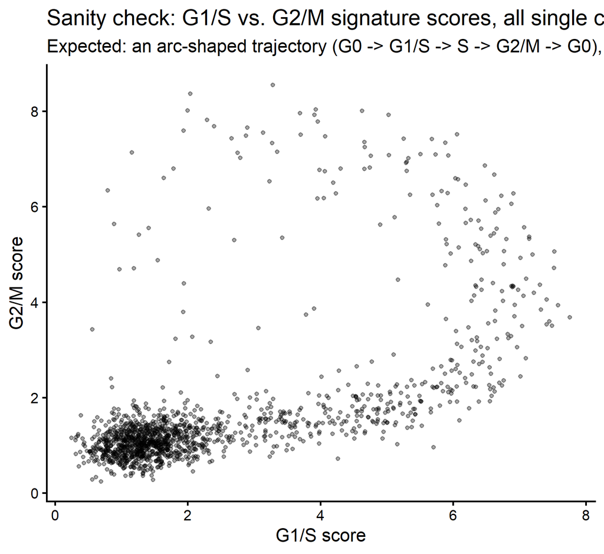

```r
ggplot(meta, aes(x = G1S_score, y = G2M_score)) +
  geom_point(alpha = 0.35, size = 1) +
  labs(title = "Sanity check: G1/S vs. G2/M signature scores, all single cells",
       subtitle = "Expected: an arc-shaped trajectory (G0 -> G1/S -> S -> G2/M -> G0), as in Fig. 2F",
       x = "G1/S score", y = "G2/M score") +
  theme_classic(base_size = 13)
```

The arc is clearly visible: a dense low/low cluster (quiescent cells) tailing off through rising G1/S values, curving up into high G2/M values, and back down - confirming the scores behave as expected before we use them for classification.

# Classifying cells into cell-cycle phases

## Biological rationale

The paper defines three functional clusters from this 2D score space: cells expressing neither program (**quiescent/G0**), cells dominated by the **G1/S** program (actively replicating DNA), and cells dominated by the **G2/M** program (preparing for/undergoing mitosis). This lets us go from a continuous score to a discrete, interpretable cell state per cell.

## Technical rationale

We use **k-means clustering (k = 3)** on the two scores, pooling *all* single cells from all cell types and ages together (so that the phase definitions are learned independently of age - we don’t want to bias the clusters toward finding an age effect). Clusters are then labelled post-hoc, using their centroid coordinates:

- the cluster with the lowest total signal (G1S + G2M) -> **G0 (non-cycling)**
- of the remaining two, the one relatively higher in G2M -> **G2/M phase**
- the other -> **G1/S phase**

```r
set.seed(1)
km <- kmeans(meta[, c("G1S_score", "G2M_score")], centers = 3, nstart = 25)
meta$cluster <- factor(km$cluster)

centers <- as.data.frame(km$centers)
centers$cluster <- rownames(km$centers)
centers$total   <- centers$G1S_score + centers$G2M_score
centers$diff    <- centers$G2M_score - centers$G1S_score

g0_id  <- centers$cluster[which.min(centers$total)]
rest   <- centers[centers$cluster != g0_id, ]
g2m_id <- rest$cluster[which.max(rest$diff)]
g1s_id <- rest$cluster[which.min(rest$diff)]

phase_map <- setNames(c("G0 (non-cycling)", "G1/S phase", "G2/M phase"),
                       c(g0_id, g1s_id, g2m_id))

meta$phase <- factor(phase_map[as.character(meta$cluster)],
                      levels = c("G0 (non-cycling)", "G1/S phase", "G2/M phase"))

knitr::kable(centers, digits = 2, caption = "k-means cluster centres (all cells pooled)")
```

k-means cluster centres (all cells pooled)

| G1S_score | G2M_score | cluster | total | diff |
| --- | --- | --- | --- | --- |
| 5.23 | 6.03 | 1 | 11.26 | 0.79 |
| 4.99 | 2.00 | 2 | 6.99 | -2.99 |
| 1.46 | 1.11 | 3 | 2.58 | -0.35 |

```r
knitr::kable(as.data.frame(table(meta$phase)), col.names = c("Phase", "N cells"),
             caption = "Cells assigned to each phase, all cell types & ages pooled")
```

Cells assigned to each phase, all cell types & ages pooled

| Phase | N cells |
| --- | --- |
| G0 (non-cycling) | 1045 |
| G1/S phase | 257 |
| G2/M phase | 127 |

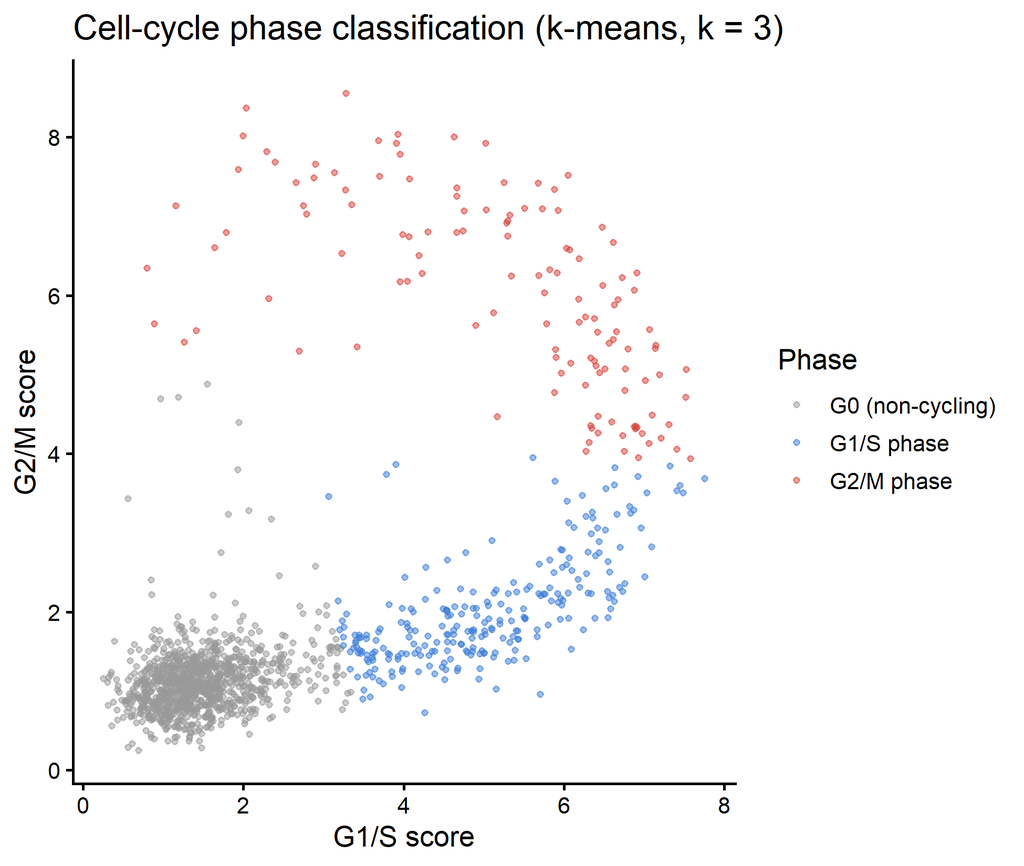

```r
ggplot(meta, aes(x = G1S_score, y = G2M_score, color = phase)) +
  geom_point(alpha = 0.5, size = 1) +
  scale_color_manual(values = c("G0 (non-cycling)" = "grey60",
                                 "G1/S phase" = "#3B7DD8",
                                 "G2/M phase" = "#D8423B")) +
  labs(title = "Cell-cycle phase classification (k-means, k = 3)",
       x = "G1/S score", y = "G2/M score", color = "Phase") +
  theme_classic(base_size = 13)
```

# Cell-cycle phase proportions: young vs. old, by cell type

## Biological rationale

If HSC aging is at least partly a **compositional** phenomenon (a shift in the proportion of cells occupying particular states, rather than every cell changing uniformly), we expect to see age-dependent shifts in the *fraction* of cells in each cell-cycle phase - and, per the paper, we expect this to be specific to LT-HSCs, since they are the population whose self-renewal/differentiation balance is thought to shift with age. ST-HSCs should show at most a weak version of the same trend, and MPPs - which are already highly proliferative progenitors - should be largely unaffected, since they’re several steps removed from the self-renewal decisions LT-HSCs face.

## Technical rationale

For each cell type we build a 2x3 contingency table (age x phase) using only the **main experimental cohort** (excluding the independently-profiled “biological replicate” cells, which we hold out as an independent replicate check). We test each phase against the other two combined using **Fisher’s exact test**, which avoids relying on large-sample approximations.

**Note:** the statistical test is performed at the single-cell level, so the cells should not be interpreted as independent biological replicates. The available biological-replicate cohort is therefore kept separate as a replicate check, and the p-values are interpreted as evidence of differences in the observed cell-level distributions rather than as formal mouse-level inference.

```r
analyse_celltype <- function(ct, label) {

  sub  <- meta[meta$celltype == ct, ]
  main <- sub[!sub$replicate, ]

  prop_tab <- as.data.frame(table(age = main$age, phase = main$phase))
  names(prop_tab)[names(prop_tab) == "Freq"] <- "n"
  prop_tab <- prop_tab[prop_tab$n > 0, ]
  prop_tab$pct <- ave(prop_tab$n, prop_tab$age, FUN = function(x) 100 * x / sum(x))

  fisher_res <- do.call(rbind, lapply(levels(main$phase), function(ph) {
    tab <- table(main$age, main$phase == ph)
    ft  <- fisher.test(tab)
    data.frame(
      phase     = ph,
      pct_young = 100 * tab["young", "TRUE"] / sum(tab["young", ]),
      pct_old   = 100 * tab["old",   "TRUE"] / sum(tab["old", ]),
      p_value   = ft$p.value,
      stringsAsFactors = FALSE
    )
  }))

  p <- ggplot(prop_tab, aes(x = age, y = pct, fill = phase)) +
    geom_col(position = "stack", color = "white", linewidth = 0.3) +
    geom_text(aes(label = paste0(round(pct, 1), "%")),
              position = position_stack(vjust = 0.5), size = 3.5, color = "white") +
    scale_fill_manual(values = c("G0 (non-cycling)" = "grey55",
                                  "G1/S phase" = "#3B7DD8",
                                  "G2/M phase" = "#D8423B")) +
    labs(title = paste0(label, ": cell-cycle phase distribution"),
         x = NULL, y = "% of cells", fill = "Phase") +
    theme_classic(base_size = 13)

  replicate_check <- NULL
  if (any(sub$replicate)) {
    rep_sub <- sub[sub$replicate, ]
    rc <- as.data.frame(table(phase = rep_sub$phase))
    names(rc)[names(rc) == "Freq"] <- "n"
    rc$pct <- 100 * rc$n / sum(rc$n)
    replicate_check <- rc
  }

  list(proportions = prop_tab, fisher = fisher_res, plot = p,
       replicate_check = replicate_check)
}
```

## (a) LT-HSC

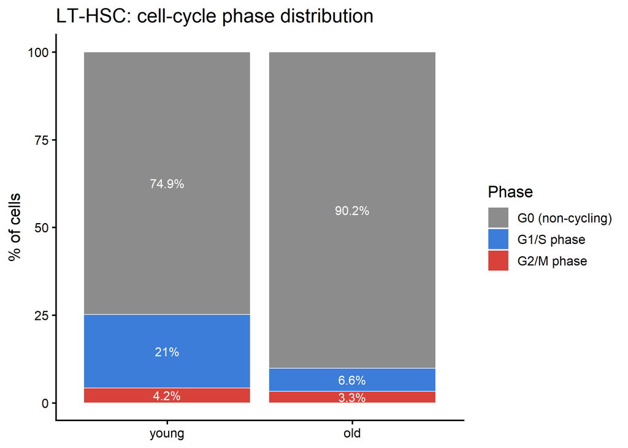

```r
res_LT <- analyse_celltype("LT_HSC", "LT-HSC")
res_LT$plot
```

```r
knitr::kable(res_LT$fisher, digits = c(0, 1, 1, 4), row.names = FALSE,
             caption = "LT-HSC: Fisher's exact test, young vs. old (each phase vs. rest)")
```

LT-HSC: Fisher’s exact test, young vs. old (each phase vs. rest)

| phase | pct_young | pct_old | p_value |
| --- | --- | --- | --- |
| G0 (non-cycling) | 74.9 | 90.2 | 0.0002 |
| G1/S phase | 21.0 | 6.6 | 0.0001 |
| G2/M phase | 4.2 | 3.3 | 0.7796 |

```r
knitr::kable(res_LT$replicate_check, digits = 1, row.names = FALSE,
             caption = "LT-HSC, old: independent biological-replicate cohort (confirmatory)")
```

LT-HSC, old: independent biological-replicate cohort (confirmatory)

| phase | n | pct |
| --- | --- | --- |
| G0 (non-cycling) | 175 | 92.6 |
| G1/S phase | 8 | 4.2 |
| G2/M phase | 6 | 3.2 |

**Interpretation.** LT-HSCs show a clear, statistically significant drop in the fraction of cells in **G1/S phase** with age, mirrored by an increase in the quiescent (G0) fraction, while G2/M is essentially unchanged. This is the paper’s headline single-cell finding: old LT-HSCs are depleted specifically in G1/S, consistent with these cells **transiting G1 faster** once they do enter cycle (rather than simply being “more quiescent” in a generic sense). The independent replicate cohort shows the same pattern, arguing against a batch artifact.

## (b) ST-HSC

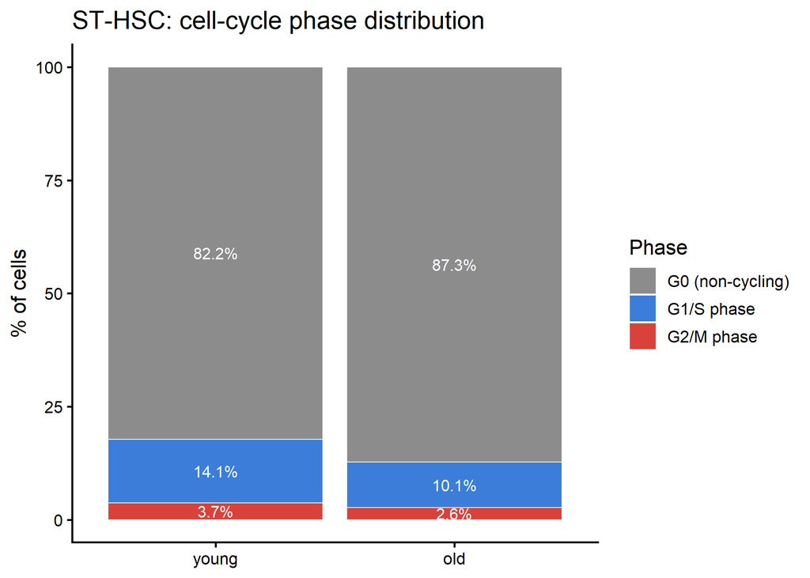

```r
res_ST <- analyse_celltype("ST_HSC", "ST-HSC")
res_ST$plot
```

```r
knitr::kable(res_ST$fisher, digits = c(0, 1, 1, 4), row.names = FALSE,
             caption = "ST-HSC: Fisher's exact test, young vs. old (each phase vs. rest)")
```

ST-HSC: Fisher’s exact test, young vs. old (each phase vs. rest)

| phase | pct_young | pct_old | p_value |
| --- | --- | --- | --- |
| G0 (non-cycling) | 82.2 | 87.3 | 0.2317 |
| G1/S phase | 14.1 | 10.1 | 0.2530 |
| G2/M phase | 3.7 | 2.6 | 0.7605 |

```r
knitr::kable(res_ST$replicate_check, digits = 1, row.names = FALSE,
             caption = "ST-HSC, old: independent biological-replicate cohort (confirmatory)")
```

ST-HSC, old: independent biological-replicate cohort (confirmatory)

| phase | n | pct |
| --- | --- | --- |
| G0 (non-cycling) | 153 | 84.5 |
| G1/S phase | 21 | 11.6 |
| G2/M phase | 7 | 3.9 |

**Interpretation.** ST-HSCs show the same general direction of change (fewer cells in G1/S and more in G0 with age), but the effect is smaller and not statistically significant in this analysis. This suggests that the age-associated pattern seen in LT-HSCs is less pronounced in ST-HSCs.

## (c) MPP

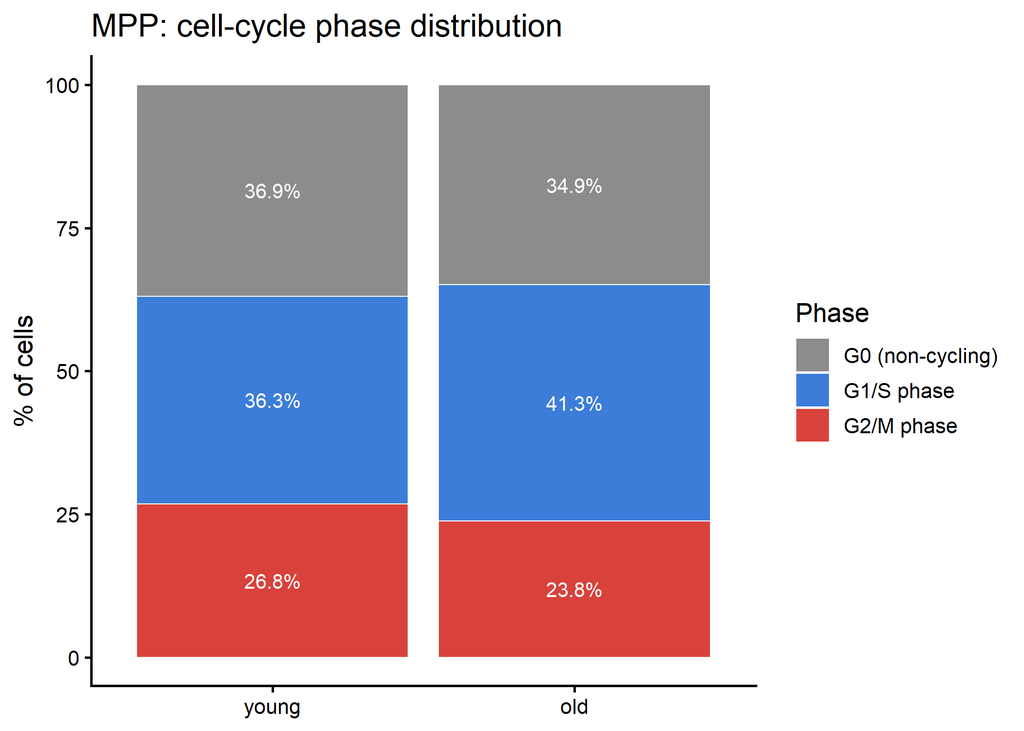

```r
res_MPP <- analyse_celltype("MPP", "MPP")
res_MPP$plot
```

```r
knitr::kable(res_MPP$fisher, digits = c(0, 1, 1, 4), row.names = FALSE,
             caption = "MPP: Fisher's exact test, young vs. old (each phase vs. rest)")
```

MPP: Fisher’s exact test, young vs. old (each phase vs. rest)

| phase | pct_young | pct_old | p_value |
| --- | --- | --- | --- |
| G0 (non-cycling) | 36.9 | 34.9 | 0.7405 |
| G1/S phase | 36.3 | 41.3 | 0.3845 |
| G2/M phase | 26.8 | 23.8 | 0.5431 |

**Interpretation.** MPPs show no statistically significant age-associated change in cell-cycle phase distribution in this analysis. They also have a larger fraction of actively cycling cells than LT-/ST-HSCs. Overall, this suggests that the age-associated change observed in LT-HSCs is not equally pronounced across all of the cell populations examined.

## Combined summary

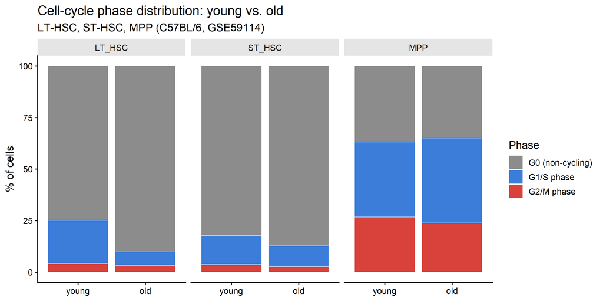

```r
main_all <- meta[!meta$replicate, ]

prop_all <- as.data.frame(table(celltype = main_all$celltype,
                                 age = main_all$age,
                                 phase = main_all$phase))
names(prop_all)[names(prop_all) == "Freq"] <- "n"
prop_all <- prop_all[prop_all$n > 0, ]
prop_all$pct <- ave(prop_all$n, interaction(prop_all$celltype, prop_all$age, drop = TRUE),
                     FUN = function(x) 100 * x / sum(x))

ggplot(prop_all, aes(x = age, y = pct, fill = phase)) +
  geom_col(position = "stack", color = "white", linewidth = 0.3) +
  facet_wrap(~ celltype, nrow = 1) +
  scale_fill_manual(values = c("G0 (non-cycling)" = "grey55",
                                "G1/S phase" = "#3B7DD8",
                                "G2/M phase" = "#D8423B")) +
  labs(title = "Cell-cycle phase distribution: young vs. old",
       subtitle = "LT-HSC, ST-HSC, MPP (C57BL/6, GSE59114)",
       x = NULL, y = "% of cells", fill = "Phase") +
  theme_classic(base_size = 13) +
  theme(strip.background = element_rect(fill = "grey90", color = NA))
```

# Cell-cycle regulator expression in G0-defined LT-HSCs

## Biological rationale

Sections (a-c) show that old LT-HSCs are depleted in cells actively transiting G1/S. A separate, complementary question is: **among cells that are already quiescent (G0) in both age groups, is their cell-cycle regulatory machinery expressed at the same level, or has quiescence itself changed with age?** If old “G0” LT-HSCs already show altered cyclin/CDK expression before ever entering cycle, that would suggest an intrinsic, pre-set bias in cell-cycle regulators - potentially explaining *why* they transit G1 faster once they re-enter the cycle, and linking to the paper’s model of a self-renewal-biased expression program in old LT-HSCs.

## Technical rationale

- We extract cell-cycle regulator genes matching cyclins (`Ccn*`), cyclin-dependent kinases (`Cdk*`), or CDK inhibitors (`Cdkn*`) directly from the full expression matrix.
- We restrict to **LT-HSC cells classified as G0 (non-cycling)** in the main cohort (from the classification above). The same computational gate is used for both ages, so any difference reflects expression differences *within* the defined G0 group rather than differences in which cells are called G0.
- For each gene we compare old vs. young with a **Wilcoxon rank-sum test** and a Welch’s t-test for reference. Benjamini-Hochberg correction is used to account for testing multiple genes.

```r
is_cyclin_cdk <- grepl(
  "^(Ccn[A-Za-z0-9]*|Cdk[A-Za-z0-9]*|Cdkn[A-Za-z0-9]*)$",
  rownames(sc_expr)
)
cc_genes <- rownames(sc_expr)[is_cyclin_cdk]
cat("Cyclin/CDK genes found in data set:", length(cc_genes), "\n")
```

```
## Cyclin/CDK genes found in data set: 40
```

```r
cat(paste(sort(cc_genes), collapse = ", "), "\n")
```

```
## Ccnb1, Ccnb2, Ccnc, Ccnd1, Ccnd2, Ccnd3, Ccndbp1, Ccne2, Ccng1, Ccnh, Ccni, Ccnj, Ccnl1, Ccnl2, Ccnt1, Ccnt2, Cdk1, Cdk10, Cdk11b, Cdk12, Cdk14, Cdk17, Cdk2, Cdk20, Cdk2ap1, Cdk2ap2, Cdk4, Cdk5, Cdk5rap1, Cdk5rap3, Cdk6, Cdk7, Cdk8, Cdkal1, Cdkn1a, Cdkn2aip, Cdkn2aipnl, Cdkn2c, Cdkn2d, Cdkn3
```

```r
cc_expr <- as.data.frame(t(sc_expr[cc_genes, , drop = FALSE]))
cc_expr$cell_id <- rownames(cc_expr)
```

```r
lt_g0_main <- meta[meta$celltype == "LT_HSC" & !meta$replicate &
                      meta$phase == "G0 (non-cycling)", ]

cc_cols <- setdiff(names(cc_expr), "cell_id")
lt_g0_main <- cbind(lt_g0_main,
                     cc_expr[match(lt_g0_main$cell_id, cc_expr$cell_id), cc_cols])

age_counts <- as.data.frame(table(age = lt_g0_main$age))
names(age_counts)[names(age_counts) == "Freq"] <- "n"

knitr::kable(age_counts, row.names = FALSE,
             caption = "Number of G0 (non-cycling) LT-HSC cells per age group, used for testing")
```

Number of G0 (non-cycling) LT-HSC cells per age group, used for testing

| age | n |
| --- | --- |
| young | 125 |
| old | 165 |

```r
test_one_gene <- function(g, df) {
  x_young <- df[[g]][df$age == "young"]
  x_old   <- df[[g]][df$age == "old"]
  wt <- tryCatch(wilcox.test(x_old, x_young)$p.value, error = function(e) NA)
  tt <- tryCatch(t.test(x_old, x_young)$p.value, error = function(e) NA)
  data.frame(
    gene       = g,
    mean_young = mean(x_young),
    mean_old   = mean(x_old),
    log2FC_old_vs_young = mean(x_old) - mean(x_young),  # already log2(TPM+1) scale
    p_wilcox   = wt,
    p_ttest    = tt,
    stringsAsFactors = FALSE
  )
}

res_tab <- do.call(rbind, lapply(cc_genes, test_one_gene, df = lt_g0_main))
res_tab$p_wilcox_adj <- p.adjust(res_tab$p_wilcox, method = "BH")
res_tab <- res_tab[order(res_tab$p_wilcox), ]
res_tab <- res_tab[, c("gene", "mean_young", "mean_old", "log2FC_old_vs_young",
                        "p_wilcox", "p_wilcox_adj", "p_ttest")]

knitr::kable(res_tab, digits = 3, row.names = FALSE,
             caption = "Cyclin/CDK genes tested in G0 LT-HSCs, old vs. young (sorted by Wilcoxon p-value)")
```

Cyclin/CDK genes tested in G0 LT-HSCs, old vs. young (sorted by Wilcoxon p-value)

| gene | mean_young | mean_old | log2FC_old_vs_young | p_wilcox | p_wilcox_adj | p_ttest |
| --- | --- | --- | --- | --- | --- | --- |
| Cdk5rap1 | 2.467 | 0.775 | -1.692 | 0.000 | 0.000 | 0.000 |
| Ccnd2 | 7.501 | 6.916 | -0.585 | 0.000 | 0.005 | 0.049 |
| Cdkn2d | 4.030 | 2.360 | -1.671 | 0.000 | 0.005 | 0.001 |
| Ccnj | 0.645 | 1.561 | 0.916 | 0.001 | 0.006 | 0.002 |
| Cdkn2c | 0.244 | 1.016 | 0.772 | 0.002 | 0.018 | 0.001 |
| Ccnb2 | 0.646 | 0.155 | -0.492 | 0.004 | 0.028 | 0.033 |
| Cdkn1a | 0.064 | 0.589 | 0.525 | 0.005 | 0.028 | 0.000 |
| Ccnt1 | 5.588 | 5.066 | -0.522 | 0.014 | 0.069 | 0.017 |
| Cdk4 | 7.666 | 6.597 | -1.069 | 0.018 | 0.081 | 0.016 |
| Cdk7 | 3.446 | 2.674 | -0.772 | 0.023 | 0.092 | 0.012 |
| Cdk11b | 3.339 | 2.600 | -0.739 | 0.034 | 0.124 | 0.055 |
| Ccnd1 | 0.586 | 0.964 | 0.379 | 0.051 | 0.169 | 0.115 |
| Cdk1 | 0.403 | 0.130 | -0.273 | 0.061 | 0.187 | 0.083 |
| Cdk17 | 1.935 | 1.339 | -0.596 | 0.069 | 0.199 | 0.082 |
| Cdk12 | 2.282 | 2.672 | 0.390 | 0.120 | 0.319 | 0.200 |
| Cdk2 | 1.890 | 1.306 | -0.585 | 0.132 | 0.330 | 0.105 |
| Ccndbp1 | 3.655 | 3.027 | -0.629 | 0.148 | 0.348 | 0.189 |
| Cdk2ap1 | 0.805 | 0.496 | -0.309 | 0.158 | 0.352 | 0.194 |
| Ccng1 | 1.319 | 1.782 | 0.463 | 0.198 | 0.414 | 0.182 |
| Cdkal1 | 1.730 | 2.064 | 0.333 | 0.207 | 0.414 | 0.333 |
| Ccnb1 | 0.694 | 0.550 | -0.144 | 0.223 | 0.424 | 0.514 |
| Cdk8 | 0.265 | 0.425 | 0.160 | 0.314 | 0.570 | 0.336 |
| Ccni | 1.739 | 1.995 | 0.256 | 0.332 | 0.578 | 0.354 |
| Ccnt2 | 3.281 | 3.008 | -0.273 | 0.354 | 0.590 | 0.545 |
| Ccne2 | 0.580 | 0.432 | -0.148 | 0.372 | 0.595 | 0.404 |
| Ccnl2 | 2.639 | 2.312 | -0.327 | 0.403 | 0.614 | 0.361 |
| Cdk6 | 1.469 | 1.622 | 0.152 | 0.414 | 0.614 | 0.334 |
| Cdkn3 | 0.178 | 0.064 | -0.114 | 0.433 | 0.619 | 0.307 |
| Cdk10 | 1.515 | 1.278 | -0.236 | 0.476 | 0.656 | 0.512 |
| Cdk5 | 1.362 | 1.304 | -0.059 | 0.559 | 0.728 | 0.860 |
| Cdkn2aipnl | 3.116 | 2.753 | -0.363 | 0.564 | 0.728 | 0.437 |
| Ccnc | 1.355 | 1.062 | -0.293 | 0.588 | 0.735 | 0.347 |
| Cdk20 | 0.667 | 0.785 | 0.118 | 0.635 | 0.744 | 0.648 |
| Cdk5rap3 | 3.862 | 3.529 | -0.333 | 0.639 | 0.744 | 0.498 |
| Ccnd3 | 4.447 | 4.746 | 0.299 | 0.651 | 0.744 | 0.304 |
| Cdk2ap2 | 2.259 | 2.464 | 0.205 | 0.710 | 0.789 | 0.642 |
| Cdkn2aip | 0.912 | 0.971 | 0.060 | 0.809 | 0.875 | 0.830 |
| Cdk14 | 3.975 | 4.153 | 0.179 | 0.850 | 0.894 | 0.236 |
| Ccnl1 | 1.881 | 1.860 | -0.021 | 0.893 | 0.916 | 0.951 |
| Ccnh | 5.463 | 5.308 | -0.155 | 0.965 | 0.965 | 0.717 |

```r
sig <- res_tab[!is.na(res_tab$p_wilcox) & res_tab$p_wilcox < 0.05, ]
knitr::kable(sig, digits = 3, row.names = FALSE,
             caption = "Genes with nominal p < 0.05 (Wilcoxon, old vs. young, within G0)")
```

Genes with nominal p < 0.05 (Wilcoxon, old vs. young, within G0)

| gene | mean_young | mean_old | log2FC_old_vs_young | p_wilcox | p_wilcox_adj | p_ttest |
| --- | --- | --- | --- | --- | --- | --- |
| Cdk5rap1 | 2.467 | 0.775 | -1.692 | 0.000 | 0.000 | 0.000 |
| Ccnd2 | 7.501 | 6.916 | -0.585 | 0.000 | 0.005 | 0.049 |
| Cdkn2d | 4.030 | 2.360 | -1.671 | 0.000 | 0.005 | 0.001 |
| Ccnj | 0.645 | 1.561 | 0.916 | 0.001 | 0.006 | 0.002 |
| Cdkn2c | 0.244 | 1.016 | 0.772 | 0.002 | 0.018 | 0.001 |
| Ccnb2 | 0.646 | 0.155 | -0.492 | 0.004 | 0.028 | 0.033 |
| Cdkn1a | 0.064 | 0.589 | 0.525 | 0.005 | 0.028 | 0.000 |
| Ccnt1 | 5.588 | 5.066 | -0.522 | 0.014 | 0.069 | 0.017 |
| Cdk4 | 7.666 | 6.597 | -1.069 | 0.018 | 0.081 | 0.016 |
| Cdk7 | 3.446 | 2.674 | -0.772 | 0.023 | 0.092 | 0.012 |
| Cdk11b | 3.339 | 2.600 | -0.739 | 0.034 | 0.124 | 0.055 |

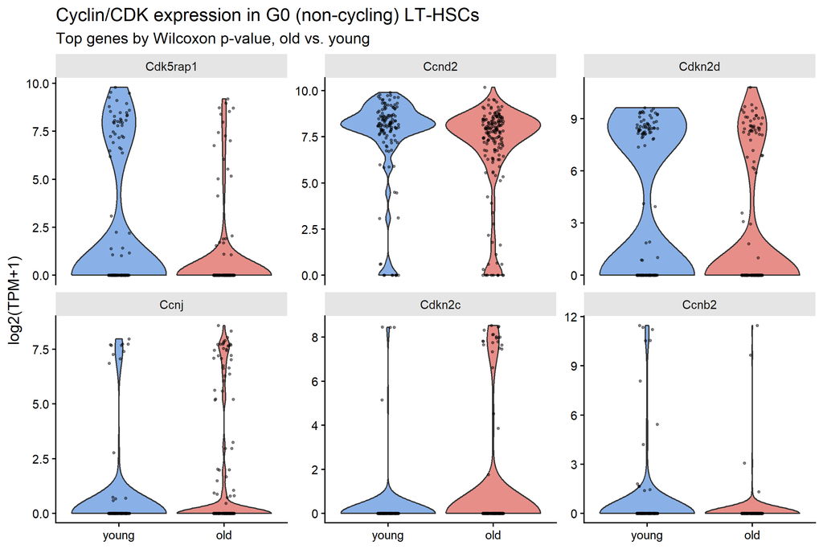

```r
top_genes <- head(res_tab$gene[!is.na(res_tab$p_wilcox)], 6)

plot_dat <- do.call(rbind, lapply(top_genes, function(g) {
  data.frame(age = lt_g0_main$age, gene = g, expr = lt_g0_main[[g]])
}))
plot_dat$gene <- factor(plot_dat$gene, levels = top_genes)

ggplot(plot_dat, aes(x = age, y = expr, fill = age)) +
  geom_violin(alpha = 0.6, scale = "width", trim = TRUE) +
  geom_jitter(width = 0.1, size = 0.6, alpha = 0.4) +
  facet_wrap(~ gene, scales = "free_y", nrow = 2) +
  scale_fill_manual(values = c(young = "#3B7DD8", old = "#D8423B")) +
  labs(title = "Cyclin/CDK expression in G0 (non-cycling) LT-HSCs",
       subtitle = "Top genes by Wilcoxon p-value, old vs. young",
       x = NULL, y = "log2(TPM+1)") +
  theme_classic(base_size = 12) +
  theme(legend.position = "none",
        strip.background = element_rect(fill = "grey90", color = NA))
```

**Interpretation.** Within the G0-defined group, several cell-cycle regulators show **nominal evidence of an age-associated difference**:

- **Cyclin D2 (*Ccnd2*)** is *lower* in old cells in the G0 group.
- The CDK inhibitors **p21 (*Cdkn1a*)** and **p18 (*Cdkn2c*)** are *higher* in old cells in the G0 group.
- *Cdk5rap1* is *lower* in old cells in the G0 group.

These differences suggest that LT-HSCs classified as G0 are not completely identical at the level of cell-cycle regulator expression across age groups. However, this analysis does not establish that the cells have different physiological states of quiescence or that any particular regulator causes the observed age-associated changes. The results are therefore best viewed as evidence of an age-associated transcriptional difference within the G0-defined population.

# Summary

| Cell type | G1/S phase, young | G1/S phase, old | Significant? |
| --- | --- | --- | --- |
| LT-HSC | ~21% | ~7% | **Yes** (difference detected) |
| ST-HSC | ~14% | ~10% | No (weaker difference) |
| MPP | ~36% | ~41% | No clear difference |

Taken together, the results suggest that age-associated changes in LT-HSCs may involve both:

1. a **change in cell-cycle composition** - fewer LT-HSCs are observed in the G1/S state in the old group (Sections a-c), and
2. **differences in cell-cycle regulator expression within the G0-defined population** (Section d).

These findings are consistent with an age-associated change in cell-cycle regulation in LT-HSCs, while the present analysis does not by itself establish the underlying mechanism or changes in cell-cycle transit time.